# MEG RT QA and backcalculation

Michael Hallquist

4 Sep 2018

## Goals

The overall goal of this document is to examine the RTs for MMClock MEG data to understand better why there are many zeros, to verify the match between the `rt` column and the clock scoring function `getScore.m`, and to recover the RTs for subjects with invalid or missing values.

## Diagnosis based on global (subject-level) statistics

Plot the association between beta (temperature) and fit ($R^2$). We expect a negative relationship, but note the subjects with extremely high $R^2$.

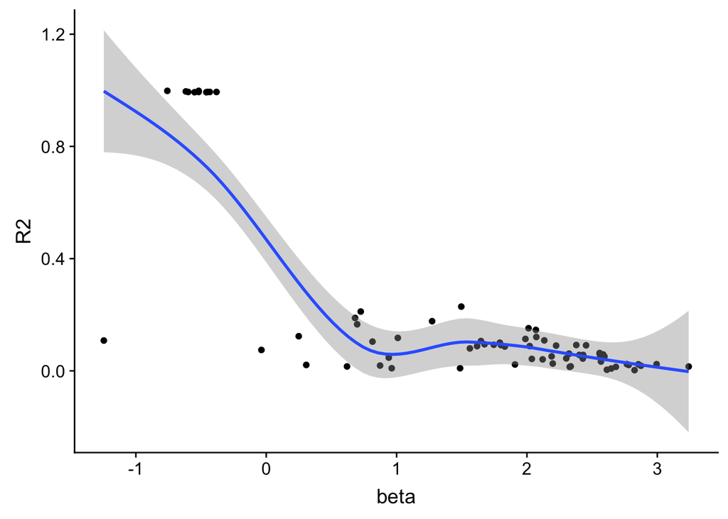

```r
ggplot(df, aes(x=beta, y=R2)) + geom_point() + stat_smooth()
```

### List subjects who had extremely high fits for unknown reasons

```r
cat(bad_r2 <- filter(df, R2 > .9) %>% pull(id), sep="\n")
```

```
## 11229_20140212
## 11280_20140926
## 11321_20140904
## 11322_20140918
## 11325_20140918
## 11331_20141120
## 11336_20141121
## 11342_20150228
## 11344_20141118
## 11346_20141230
```

## Diagnosis of trial-level RTs

Let’s now load the trial-level statistics for the MEG dataset for more a detailed examination

### Distribution of RTs for subjects with excessive R2

It turns out that those high $R^2$ subjects have all zeros for RTs.

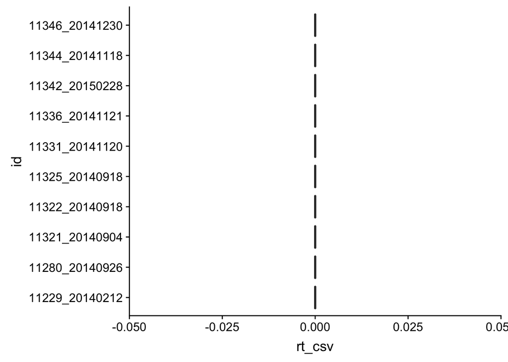

```r
ggplot(tdf %>% filter(id %in% bad_r2), aes(x=id, y=rt_csv)) + geom_boxplot() + coord_flip()
```

```r
# Prior to joining on the ascending trial (i.e., the trials fitted by the computational model), the subjects with gaps in the trial sequence
# would have improper trial joins (since the MATLAB output reflected ascending trial, but the original CSVs have trial that jumps at missing run boundaries)
# This is now corrected upstream by using asc_trial as the join column. Keeping here for documentation only.
# FORMER PROBLEM: some rows are missing key information such as rewFunc (contingency)
#miss_stuff <- tdf %>% filter(is.na(rewFunc)) %>% write_csv(path="meg_missing_info.csv")
```

Write out a CSV with zero RTs for further diagnosis.

```r
zero_rts <- tdf %>% filter(rt_csv==0) %>%
  select(id, run, trial, rewFunc, emotion, rt_csv, rt_backcalc, score_csv, magnitude, probability, ev) %>%
  arrange(id, run, trial)

head(zero_rts)
```

| id | run | trial | rewFunc | emotion | rt_csv | rt_backcalc | score_csv | magnitude | probability | ev |
| --- | --- | --- | --- | --- | --- | --- | --- | --- | --- | --- |
| 10637_20140312 | 2 | 113 | IEV | happy | 0 | 34 | 13 | 13 | 0.900 | 11.4 |
| 10637_20140312 | 2 | 123 | IEV | happy | 0 | 14 | 16 | 16 | 0.900 | 14.1 |
| 10637_20140312 | 3 | 148 | CEVR | scram | 0 | 5 | 0 | 182 | 0.206 | 37.4 |
| 10637_20140312 | 4 | 250 | DEV | fear | 0 | 1353 | 0 | 78 | 0.574 | 44.9 |
| 10637_20140312 | 5 | 257 | IEV | scram | 0 | 17 | 14 | 14 | 0.900 | 12.3 |
| 10637_20140312 | 5 | 270 | IEV | scram | 0 | 4018 | 0 | 141 | 0.373 | 52.8 |

```r
#cache for visual examination
write_csv(x=zero_rts, path="output/zero_rts.csv")
```

The number of rows with RT = 0 is 5197.

Now look at subjects missing some, but not all, RTs. These seem to merit further consideration, as this isn’t attributable to a bug that dropped all RTs.

```r
zero_rts_some <- zero_rts %>% filter(!id %in% bad_r2)
head(zero_rts_some)
```

| id | run | trial | rewFunc | emotion | rt_csv | rt_backcalc | score_csv | magnitude | probability | ev |
| --- | --- | --- | --- | --- | --- | --- | --- | --- | --- | --- |
| 10637_20140312 | 2 | 113 | IEV | happy | 0 | 34 | 13 | 13 | 0.900 | 11.4 |
| 10637_20140312 | 2 | 123 | IEV | happy | 0 | 14 | 16 | 16 | 0.900 | 14.1 |
| 10637_20140312 | 3 | 148 | CEVR | scram | 0 | 5 | 0 | 182 | 0.206 | 37.4 |
| 10637_20140312 | 4 | 250 | DEV | fear | 0 | 1353 | 0 | 78 | 0.574 | 44.9 |
| 10637_20140312 | 5 | 257 | IEV | scram | 0 | 17 | 14 | 14 | 0.900 | 12.3 |
| 10637_20140312 | 5 | 270 | IEV | scram | 0 | 4018 | 0 | 141 | 0.373 | 52.8 |

```r
write_csv(x=zero_rts_some, path="output/zero_rts_not_all.csv")
```

The number of rows with RT = 0 that doesn’t reflect a subject missing all RTs is 283.

What about RTs > 4000? This could result from the ‘Flip’ in PsychToolbox falling just outside the trial loop. So these are not necessarily invalid, and if I recall, the subject does get an omission no matter what if they don’t respond within the 4000ms window.

Number of rows with RT > 4000: 8.

## Validate backcalculation function

The `RewFunction_Reversed` function calculates RT based on the condition and reward frequency recorded in the CSV file. The frequency should yield a one-to-one mapping between RT and reward probability, whereas EV wouldn’t (e.g., in constant expected value).

First, let’s make sure the lookup table used in backcalculation matches our a prior expectation.

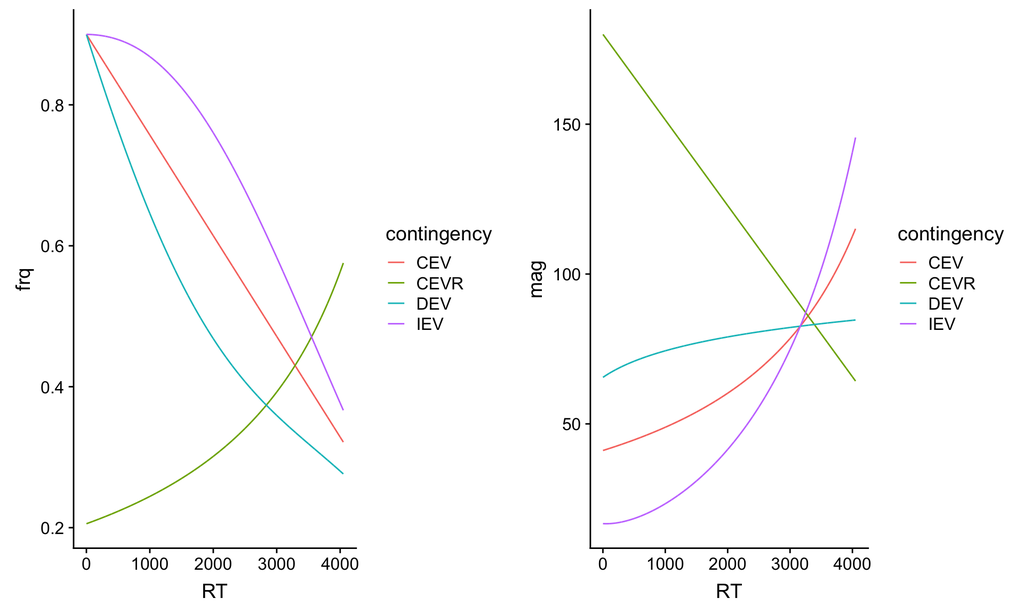

```r
#double check the probability -> RT lookup structure to make sure nothing is improper there
lookup_df <- as.data.frame(lookup) %>% gather(key="frqmag", value="value", -RT) %>%
  separate(frqmag, into=c("contingency", "frqmag"), sep="_") %>% spread(key=frqmag, value=value)

frqplot <- ggplot(lookup_df, aes(x=RT, y=frq, color=contingency)) + geom_line()
magplot <- ggplot(lookup_df, aes(x=RT, y=mag, color=contingency)) + geom_line()

#yep, looks right!
plot_grid(frqplot, magplot, align="h")
```

## Validate backcalculation of RTs

Let’s next validate the function on a subject with good RTs: 11262_20140312. The RTs should match!

```r
subj_to_diagnose <- "11262_20140312"
#subj_to_diagnose <- "11343_20150110" #(other MEG subj)
#subj_to_diagnose <- 10637 #fmri comparator

one_subj <- tdf %>% filter(id==subj_to_diagnose)
one_subj$trial_rel <- 1:trials_per_run #use recycling to propagate to all runs

tocorr <- one_subj %>% select(trial, trial_rel, rewFunc, emotion, rt_csv, rt_backcalc, rt_vba, probability, magnitude) %>%
  mutate(rt_vba=rt_vba*100, rt_discrep=rt_csv - rt_backcalc, condition=paste(rewFunc, emotion, sep="_"))
```

Number of rows in our test case where RT = 0: 0.

Number of rows in test case where RT from CSV > 4000: 0. Number of rows in test case where backcalculated RT > 4000: 0.

Correlations between RTs in CSV file and back-calculated RTs:

```r
xx <- split(tocorr, tocorr$condition)

lapply(xx, function(df) { cor(df$rt_csv, df$rt_backcalc, use="pairwise.complete.obs")})
```

```
## $CEV_scram
## [1] 1
##
## $CEVR_scram
## [1] 1
##
## $DEV_fear
## [1] 0.998
##
## $DEV_happy
## [1] 0.998
##
## $DEV_scram
## [1] 1
##
## $IEV_fear
## [1] 1
##
## $IEV_happy
## [1] 1
##
## $IEV_scram
## [1] 1
```

```r
#sum(is.na(tocorr$rt_backcalc))
```

### 20 randomly sampled rows with Discrepancies of > 100ms in recorded versus backcalculated RTs in subject

```r
filter(tocorr, abs(rt_discrep) > 100) %>% sample_n(20) %>% kable()
```

| trial | trial_rel | rewFunc | emotion | rt_csv | rt_backcalc | rt_vba | probability | magnitude | rt_discrep | condition |
| --- | --- | --- | --- | --- | --- | --- | --- | --- | --- | --- |
| 253 | 1 | IEV | scram | 673 | 805 | 673 | 0.880 | 26 | -132 | IEV_scram |
| 317 | 2 | DEV | happy | 512 | 629 | 512 | 0.732 | 76 | -117 | DEV_happy |
| 269 | 17 | IEV | scram | 1519 | 1628 | 1519 | 0.810 | 33 | -109 | IEV_scram |
| 482 | 41 | DEV | scram | 639 | 742 | 639 | 0.705 | 71 | -103 | DEV_scram |
| 494 | 53 | DEV | scram | 524 | 637 | 524 | 0.730 | 69 | -113 | DEV_scram |
| 404 | 26 | IEV | fear | 1616 | 1750 | 1616 | 0.795 | 41 | -134 | IEV_fear |
| 388 | 10 | IEV | fear | 1453 | 1556 | 1453 | 0.818 | 29 | -103 | IEV_fear |
| 303 | 51 | IEV | scram | 1847 | 1968 | 1847 | 0.765 | 40 | -121 | IEV_scram |
| 257 | 5 | IEV | scram | 1794 | 1911 | 1794 | 0.773 | 36 | -117 | IEV_scram |
| 354 | 39 | DEV | happy | 265 | 383 | 265 | 0.795 | 74 | -118 | DEV_happy |
| 346 | 31 | DEV | happy | 295 | 404 | 295 | 0.789 | 67 | -109 | DEV_happy |
| 358 | 43 | DEV | happy | 223 | 334 | 223 | 0.808 | 66 | -111 | DEV_happy |
| 476 | 35 | DEV | scram | 438 | 560 | 438 | 0.749 | 73 | -122 | DEV_scram |
| 361 | 46 | DEV | happy | 321 | 448 | 321 | 0.778 | 68 | -127 | DEV_happy |
| 405 | 27 | IEV | fear | 1508 | 1632 | 1508 | 0.809 | 37 | -124 | IEV_fear |
| 420 | 42 | IEV | fear | 1651 | 1761 | 1651 | 0.793 | 31 | -110 | IEV_fear |
| 411 | 33 | IEV | fear | 1626 | 1742 | 1626 | 0.796 | 38 | -116 | IEV_fear |
| 418 | 40 | IEV | fear | 1642 | 1765 | 1642 | 0.793 | 32 | -123 | IEV_fear |
| 475 | 34 | DEV | scram | 475 | 601 | 475 | 0.739 | 72 | -126 | DEV_scram |
| 285 | 33 | IEV | scram | 1354 | 1481 | 1354 | 0.826 | 32 | -127 | IEV_scram |

### Plot of recorded versus backcalculated RTs in subject 11262_20140312

```r
#tocorr %>% filter(is.na(rt_backcalc))

toplot <- tocorr %>% gather(key="rtsrc", value="rt", rt_csv, rt_backcalc) %>% select(-rt_vba)
```

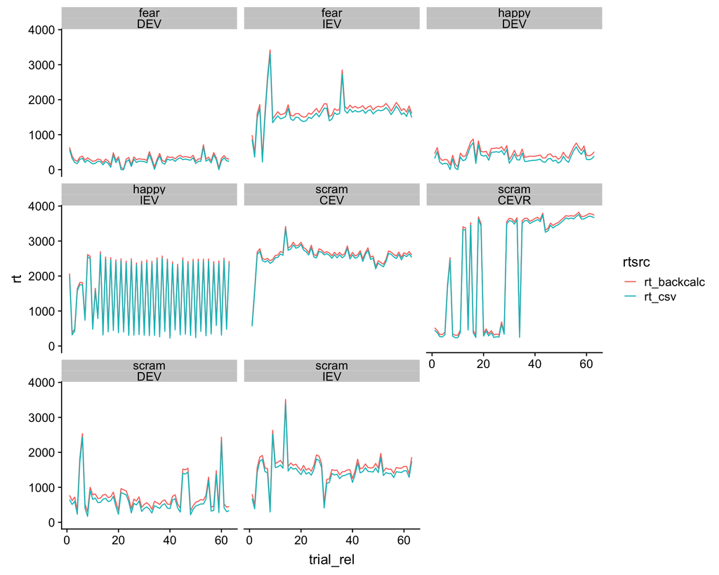

```r
ggplot(toplot, aes(x=trial_rel, y=rt, color=rtsrc)) + geom_line() + facet_wrap(~emotion*rewFunc)
```

### Plot of the distribution of differences in recorded versus backcalculated RTs

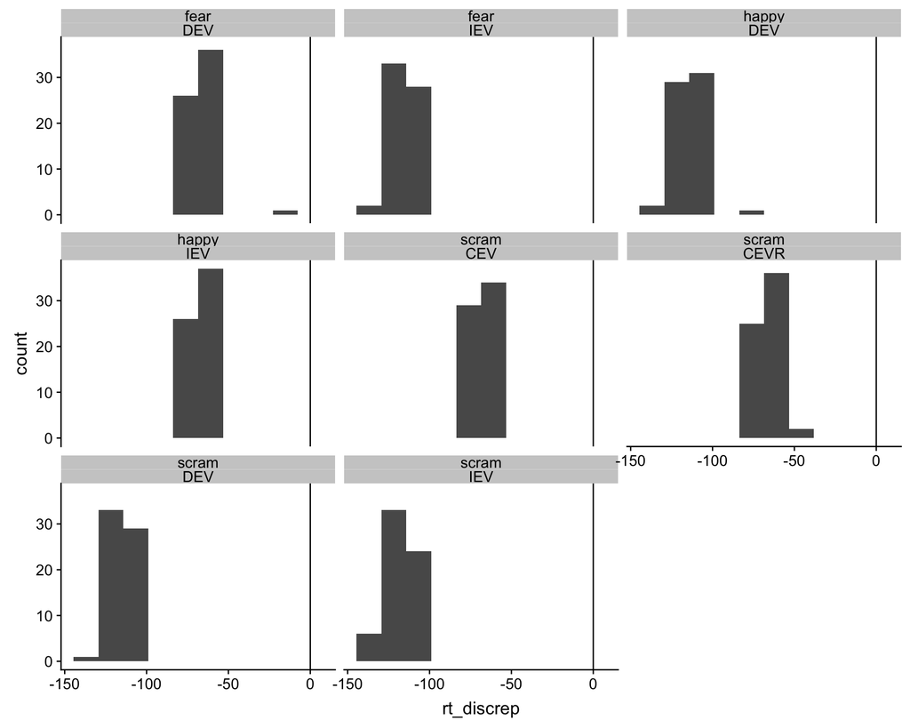

```r
ggplot(tocorr, aes(x=rt_discrep)) + geom_histogram(bins=10) + facet_wrap(~emotion*rewFunc) + geom_vline(xintercept=0)
```

The `rt_discrep` column is calculated: `rt_csv - rt_backcalc`. Thus, the consistently negative values seen here indicate that the recorded RTs in the CSV file are faster than the backcalculated RTs. The reason for this difference remains to be investigated.

## Scaling up these checks to all subjects

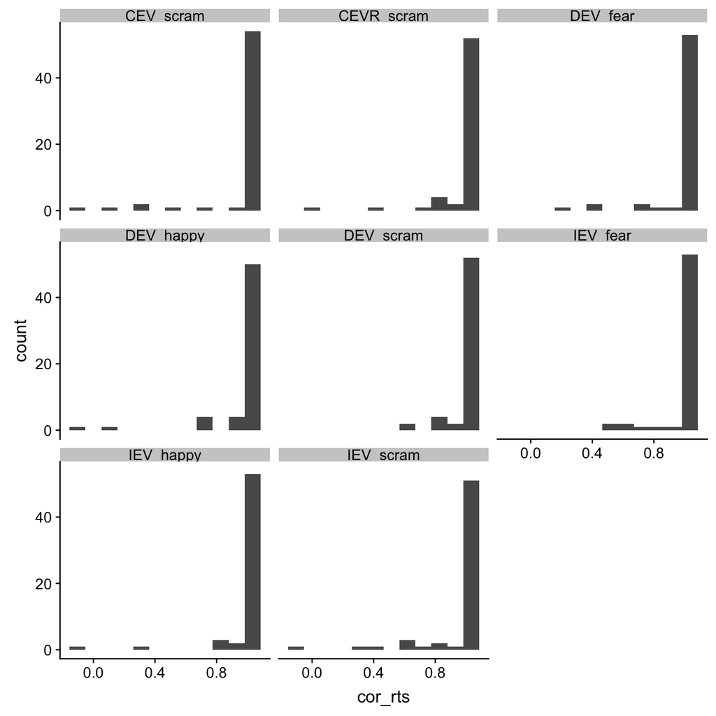

```r
tdf <- tdf %>% group_by(id, run) %>% arrange(trial) %>% mutate(trial_rel = 1:n()) %>% ungroup()
cor_diagnosis <- tdf %>% filter(!id %in% bad_r2) %>% #drop cases with all zeros since the correlation is meaningless
  select(id, trial, trial_rel, rewFunc, emotion, rt_csv, rt_backcalc, rt_vba, probability, magnitude) %>%
  mutate(rt_vba=rt_vba*100, rt_discrep=rt_csv - rt_backcalc, condition=paste(rewFunc, emotion, sep="_"))

cor_match <- function(rt_csv, rt_backcalc) {
  if (sd(rt_csv, na.rm = T) == 0 || sd(rt_backcalc, na.rm=T) == 0) {
    return(NA)
  } else {
    return(cor(rt_csv, rt_backcalc, use="pairwise.complete.obs"))
  }
}

results <- cor_diagnosis %>% group_by(id, condition) %>% summarize(cor_rts=cor_match(rt_csv, rt_backcalc)) %>% ungroup()

ggplot(results, aes(x=cor_rts)) + geom_histogram(bins=12) + facet_wrap(~condition)
```

Are there subjects where there is no discrepancy between the backcalc and the csv? It appears not.

```r
max_discrep <- cor_diagnosis %>% group_by(id) %>% summarize(rt_max_discrep=max(abs(rt_discrep))) %>% arrange(rt_max_discrep)
kable(max_discrep)
```

| id | rt_max_discrep |
| --- | --- |
| 11320_20140908 | 78 |
| 11311_20140808 | 79 |
| 11255_20140318 | 80 |
| 11243_20140213 | 122 |
| 10772_20140509 | 128 |
| 11366_20150430 | 128 |
| 11304_20140722 | 131 |
| 11302_20140826 | 132 |
| 10895_20140709 | 133 |
| 11162_20140708 | 133 |
| 11250_20140422 | 133 |
| 11335_20141103 | 133 |
| 11345_20141229 | 133 |
| 10662_20140415 | 134 |
| 10767_20140828 | 134 |
| 11263_20140324 | 134 |
| 11288_20140711 | 134 |
| 11337_20141111 | 134 |
| 11277_20140519 | 135 |
| 11319_20140924 | 135 |
| 11324_20141009 | 135 |
| 10873_20141014 | 136 |
| 11258_20140303 | 136 |
| 11278_20140505 | 136 |
| 11316_20140829 | 136 |
| 11318_20141029 | 136 |
| 10711_20140825 | 137 |
| 11262_20140312 | 137 |
| 11310_20140807 | 137 |
| 11313_20141104 | 137 |
| 11315_20140815 | 137 |
| 11282_20141030 | 139 |
| 10811_20140801 | 140 |
| 10891_20140925 | 145 |
| 10997_20140221 | 149 |
| 11347_20141217 | 195 |
| 11317_20141009 | 284 |
| 11353_20141230 | 326 |
| 11265_20140923 | 547 |
| 11328_20141023 | 865 |
| 11228_20140911 | 1378 |
| 11326_20141006 | 2633 |
| 11253_20140219 | 2997 |
| 11350_20141204 | 3444 |
| 11274_20140528 | 4016 |
| 10637_20140312 | 4018 |
| 11329_20141105 | 4018 |
| 10822_20140703 | 4026 |
| 10638_20140516 | 4029 |
| 11178_20140515 | 4032 |
| 11216_20141008 | 4032 |
| 11275_20140620 | 4032 |
| 11279_20140507 | 4032 |
| 11287_20140522 | 4032 |
| 11314_20141020 | 4032 |
| 11323_20141209 | 4032 |
| 11343_20150110 | 4032 |
| 10814_20140807 | 4033 |
| 11246_20140218 | 4033 |
| 11305_20140825 | 4033 |
| 11338_20141110 | 4033 |

### Zoom in on cases where correlation is < .99

```r
bad_cases <- results %>% filter(cor_rts < .99) #slight rounding challenges due to machine precision
kable(bad_cases)
```

| id | condition | cor_rts |
| --- | --- | --- |
| 10637_20140312 | DEV_fear | 0.979 |
| 10637_20140312 | IEV_scram | 0.830 |
| 10638_20140516 | CEVR_scram | 0.814 |
| 10638_20140516 | IEV_scram | 0.647 |
| 10814_20140807 | CEVR_scram | 0.394 |
| 10814_20140807 | DEV_fear | 0.193 |
| 10814_20140807 | IEV_fear | 0.718 |
| 10814_20140807 | IEV_scram | 0.281 |
| 10822_20140703 | CEVR_scram | 0.846 |
| 10822_20140703 | IEV_happy | 0.892 |
| 11178_20140515 | DEV_fear | 0.735 |
| 11178_20140515 | DEV_scram | 0.599 |
| 11178_20140515 | IEV_fear | 0.642 |
| 11216_20141008 | DEV_happy | 0.680 |
| 11228_20140911 | DEV_happy | 0.980 |
| 11246_20140218 | CEV_scram | 0.308 |
| 11246_20140218 | DEV_happy | 0.954 |
| 11246_20140218 | DEV_scram | 0.931 |
| 11246_20140218 | IEV_happy | -0.084 |
| 11253_20140219 | IEV_scram | -0.137 |
| 11274_20140528 | CEV_scram | 0.485 |
| 11275_20140620 | CEVR_scram | 0.861 |
| 11275_20140620 | DEV_scram | 0.818 |
| 11275_20140620 | IEV_fear | 0.561 |
| 11275_20140620 | IEV_happy | 0.797 |
| 11275_20140620 | IEV_scram | 0.624 |
| 11279_20140507 | CEVR_scram | 0.765 |
| 11279_20140507 | DEV_fear | 0.678 |
| 11279_20140507 | DEV_happy | 0.756 |
| 11279_20140507 | IEV_fear | 0.481 |
| 11279_20140507 | IEV_happy | 0.887 |
| 11279_20140507 | IEV_scram | 0.671 |
| 11287_20140522 | DEV_fear | 0.833 |
| 11287_20140522 | DEV_happy | 0.756 |
| 11287_20140522 | IEV_scram | 0.856 |
| 11305_20140825 | CEV_scram | 0.772 |
| 11305_20140825 | CEVR_scram | 0.902 |
| 11305_20140825 | DEV_fear | 0.398 |
| 11305_20140825 | DEV_happy | 0.898 |
| 11305_20140825 | DEV_scram | 0.869 |
| 11305_20140825 | IEV_fear | 0.893 |
| 11305_20140825 | IEV_happy | 0.801 |
| 11305_20140825 | IEV_scram | 0.891 |
| 11314_20141020 | CEV_scram | -0.059 |
| 11314_20141020 | CEVR_scram | 0.803 |
| 11314_20141020 | DEV_happy | -0.061 |
| 11314_20141020 | DEV_scram | 0.796 |
| 11314_20141020 | IEV_fear | 0.784 |
| 11314_20141020 | IEV_happy | 0.841 |
| 11314_20141020 | IEV_scram | 0.990 |
| 11323_20141209 | DEV_happy | 0.746 |
| 11323_20141209 | DEV_scram | 0.578 |
| 11323_20141209 | IEV_fear | 0.647 |
| 11323_20141209 | IEV_scram | 0.368 |
| 11326_20141006 | CEV_scram | 0.928 |
| 11329_20141105 | CEV_scram | 0.079 |
| 11338_20141110 | CEVR_scram | 0.883 |
| 11338_20141110 | DEV_happy | 0.891 |
| 11343_20150110 | CEV_scram | 0.358 |
| 11343_20150110 | CEVR_scram | 0.047 |
| 11343_20150110 | DEV_fear | 0.448 |
| 11343_20150110 | DEV_happy | 0.099 |
| 11343_20150110 | DEV_scram | 0.816 |
| 11343_20150110 | IEV_happy | 0.353 |
| 11343_20150110 | IEV_scram | 0.685 |
| 11350_20141204 | DEV_scram | 0.947 |

### Find a case with lots of discrepancies

Find a subject where many/all runs have low correlations.

```r
kable(bad_freq <- table(bad_cases$id))
```

| Var1 | Freq |
| --- | --- |
| 10637_20140312 | 2 |
| 10638_20140516 | 2 |
| 10814_20140807 | 4 |
| 10822_20140703 | 2 |
| 11178_20140515 | 3 |
| 11216_20141008 | 1 |
| 11228_20140911 | 1 |
| 11246_20140218 | 4 |
| 11253_20140219 | 1 |
| 11274_20140528 | 1 |
| 11275_20140620 | 5 |
| 11279_20140507 | 6 |
| 11287_20140522 | 3 |
| 11305_20140825 | 8 |
| 11314_20141020 | 7 |
| 11323_20141209 | 4 |
| 11326_20141006 | 1 |
| 11329_20141105 | 1 |
| 11338_20141110 | 2 |
| 11343_20150110 | 7 |
| 11350_20141204 | 1 |

```r
worst <- names(bad_freq)[which.max(bad_freq)]
```

Looks like 11305_20140825 is the ID with the most discrepancies. Repeat the plot above to get a sense of discrepancies:

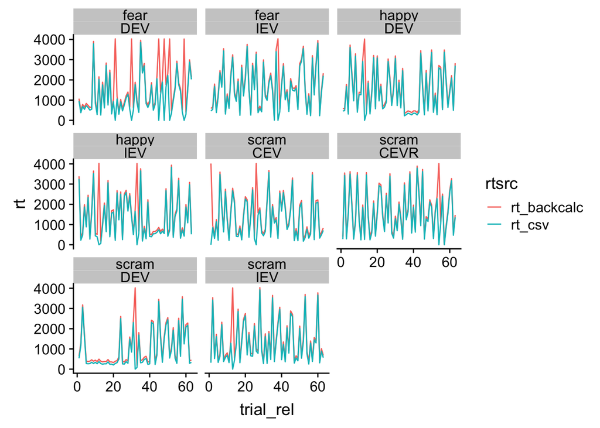

```r
worst_subj <- cor_diagnosis %>% filter(id==worst)
ggplot(worst_subj %>% gather(key="rtsrc", value="rt", rt_csv, rt_backcalc), aes(x=trial_rel, y=rt, color=rtsrc)) + geom_line() + facet_wrap(~emotion*rewFunc)
```

The low correlation appears to stem from a number of very high RT ~ 4000ms values in the backcalculated RTs.

```r
filter(worst_subj, rt_backcalc > 3990)
```

| id | trial | trial_rel | rewFunc | emotion | rt_csv | rt_backcalc | rt_vba | probability | magnitude | rt_discrep | condition |
| --- | --- | --- | --- | --- | --- | --- | --- | --- | --- | --- | --- |
| 11305_20140825 | 1 | 1 | CEV | scram | 0 | 4018 | 0 | 0.326 | 111 | -4018 | CEV_scram |
| 11305_20140825 | 26 | 26 | CEV | scram | 0 | 4024 | 0 | 0.325 | 116 | -4024 | CEV_scram |
| 11305_20140825 | 75 | 12 | IEV | happy | 0 | 4028 | 0 | 0.371 | 140 | -4028 | IEV_happy |
| 11305_20140825 | 96 | 33 | IEV | happy | 0 | 4024 | 0 | 0.372 | 139 | -4024 | IEV_happy |
| 11305_20140825 | 180 | 54 | CEVR | scram | 0 | 4021 | 0 | 0.568 | 67 | -4021 | CEVR_scram |
| 11305_20140825 | 210 | 21 | DEV | fear | 0 | 4031 | 0 | 0.278 | 87 | -4031 | DEV_fear |
| 11305_20140825 | 219 | 30 | DEV | fear | 0 | 4025 | 0 | 0.278 | 87 | -4025 | DEV_fear |
| 11305_20140825 | 234 | 45 | DEV | fear | 0 | 4025 | 0 | 0.278 | 82 | -4025 | DEV_fear |
| 11305_20140825 | 237 | 48 | DEV | fear | 0 | 4025 | 0 | 0.278 | 84 | -4025 | DEV_fear |
| 11305_20140825 | 240 | 51 | DEV | fear | 0 | 4024 | 0 | 0.278 | 84 | -4024 | DEV_fear |
| 11305_20140825 | 248 | 59 | DEV | fear | 0 | 4022 | 0 | 0.279 | 85 | -4022 | DEV_fear |
| 11305_20140825 | 265 | 13 | IEV | scram | 0 | 4018 | 0 | 0.373 | 138 | -4018 | IEV_scram |
| 11305_20140825 | 280 | 28 | IEV | scram | 3920 | 4031 | 3920 | 0.370 | 140 | -111 | IEV_scram |
| 11305_20140825 | 328 | 13 | DEV | happy | 0 | 4021 | 0 | 0.279 | 89 | -4021 | DEV_happy |
| 11305_20140825 | 416 | 38 | IEV | fear | 0 | 4033 | 0 | 0.370 | 140 | -4033 | IEV_fear |
| 11305_20140825 | 473 | 32 | DEV | scram | 0 | 4021 | 0 | 0.279 | 89 | -4021 | DEV_scram |

At first glance, it appears that the correlations are substantially damaged by RTs in the CSV that are zero. Is it possible that these reflect ‘missed’ RTs? Does the correlation get better if we treat these as `NA` for now?

Before:

```r
worst_subj %>% group_by(condition) %>% summarize(cor_rts=cor_match(rt_csv, rt_backcalc))
```

| condition | cor_rts |
| --- | --- |
| CEV_scram | 0.772 |
| CEVR_scram | 0.902 |
| DEV_fear | 0.398 |
| DEV_happy | 0.898 |
| DEV_scram | 0.869 |
| IEV_fear | 0.893 |
| IEV_happy | 0.801 |
| IEV_scram | 0.891 |

After:

```r
worst_subj <- worst_subj %>% mutate(rt_backcalc=if_else(rt_backcalc >= 4000, NA_integer_, rt_backcalc))
worst_subj %>% group_by(condition) %>% summarize(cor_rts=cor_match(rt_csv, rt_backcalc))
```

| condition | cor_rts |
| --- | --- |
| CEV_scram | 1 |
| CEVR_scram | 1 |
| DEV_fear | 1 |
| DEV_happy | 1 |
| DEV_scram | 1 |
| IEV_fear | 1 |
| IEV_happy | 1 |
| IEV_scram | 1 |

The plot after:

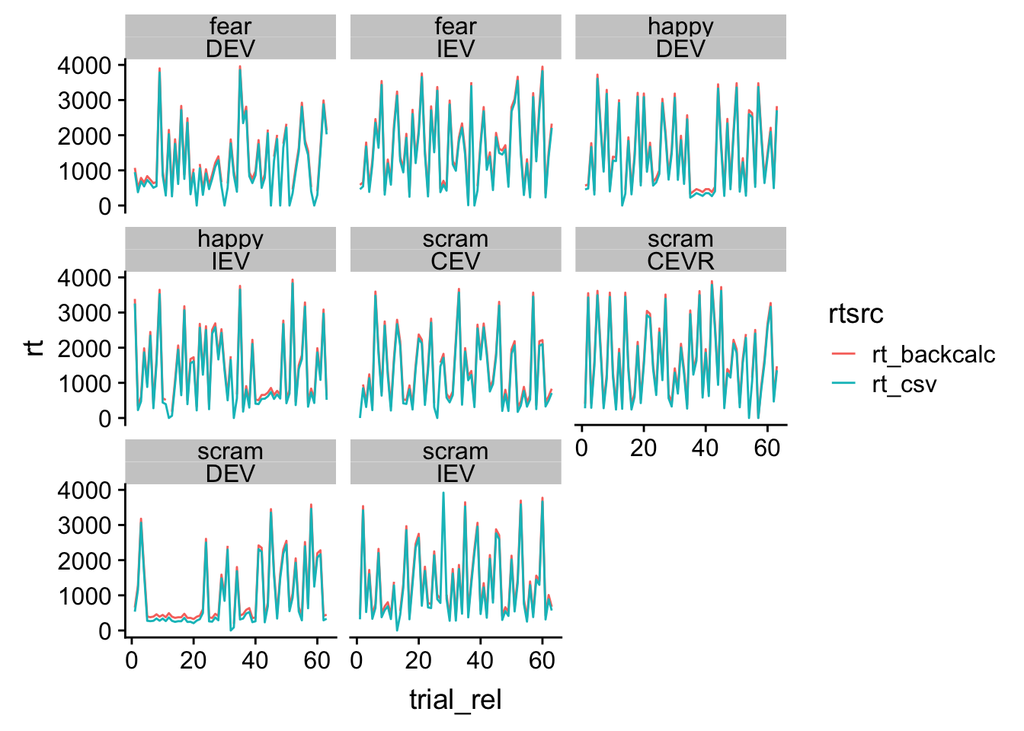

```r
ggplot(worst_subj %>% gather(key="rtsrc", value="rt", rt_csv, rt_backcalc), aes(x=trial_rel, y=rt, color=rtsrc)) + geom_line() + facet_wrap(~emotion*rewFunc)
```

## Provisional diagnosis of large gaps between rt_csv and rt_backcalc

In the subject above, the rt_backcalc was > 4000ms when rt_csv was 0. This suggests that:

1. The subject probably failed to respond on this trial, and the probability column reflects the time at which the trial ended (~4000ms).
2. If this is true, we should likely use the rt_backcalc instead of the 0 because this is closer to the lived experience – the subject waited to a late moment in time and got an omission.
3. We should verify that the vast majority of rt_backcalc values > 4000 are associated with rt_csv = 0. There may be some late valid rt_csv responses (e.g., 3950ms), that roll over to 4000+ in backcalculation. The ~100ms discrepancy noted above seems to stem from a different source.
4. If these considerations are corroborated, when rt_csv is 0, we should use the rt_backcalc in place of the 0 in all modeling.

### Examining the rt_csv values of 0 for subjects with otherwise valid RTs

Let’s return to the `zero_rts_some` dataset above, which has subjects with some zero RTs but also a large number of non-zero RTs. Let’s further divide into cases where rt_backcalc is > 3950 versus those that are not.

```r
head(zero_rts_some)
```

| id | run | trial | rewFunc | emotion | rt_csv | rt_backcalc | score_csv | magnitude | probability | ev |
| --- | --- | --- | --- | --- | --- | --- | --- | --- | --- | --- |
| 10637_20140312 | 2 | 113 | IEV | happy | 0 | 34 | 13 | 13 | 0.900 | 11.4 |
| 10637_20140312 | 2 | 123 | IEV | happy | 0 | 14 | 16 | 16 | 0.900 | 14.1 |
| 10637_20140312 | 3 | 148 | CEVR | scram | 0 | 5 | 0 | 182 | 0.206 | 37.4 |
| 10637_20140312 | 4 | 250 | DEV | fear | 0 | 1353 | 0 | 78 | 0.574 | 44.9 |
| 10637_20140312 | 5 | 257 | IEV | scram | 0 | 17 | 14 | 14 | 0.900 | 12.3 |
| 10637_20140312 | 5 | 270 | IEV | scram | 0 | 4018 | 0 | 141 | 0.373 | 52.8 |

Number of examples of rt_csv == 0, but rt_backcalc != 0 is: 283.

### Cases where rt_csv is zero and rt_backcalc is > 4000

Provisional diagnosis: this reflects failed responses.

Number of rows where rt_backcalc is > 3950 and rt_csv is 0: 185.

```r
kable(filter(zero_rts_some, rt_csv==0 & rt_backcalc > 3950))
```

| id | run | trial | rewFunc | emotion | rt_csv | rt_backcalc | score_csv | magnitude | probability | ev |
| --- | --- | --- | --- | --- | --- | --- | --- | --- | --- | --- |
| 10637_20140312 | 5 | 270 | IEV | scram | 0 | 4018 | 0 | 141 | 0.373 | 52.8 |
| 10638_20140516 | 3 | 172 | CEVR | scram | 0 | 4023 | 0 | 67 | 0.569 | 38.1 |
| 10638_20140516 | 5 | 291 | IEV | scram | 0 | 4029 | 0 | 141 | 0.371 | 52.5 |
| 10638_20140516 | 5 | 306 | IEV | scram | 0 | 4026 | 0 | 145 | 0.372 | 53.9 |
| 10814_20140807 | 5 | 284 | IEV | fear | 0 | 4023 | 0 | 148 | 0.372 | 55.0 |
| 10814_20140807 | 5 | 298 | IEV | fear | 0 | 4031 | 0 | 142 | 0.370 | 52.5 |
| 10814_20140807 | 5 | 306 | IEV | fear | 0 | 4032 | 0 | 141 | 0.370 | 52.1 |
| 10814_20140807 | 6 | 325 | CEVR | scram | 0 | 4023 | 0 | 70 | 0.569 | 39.8 |
| 10814_20140807 | 6 | 351 | CEVR | scram | 0 | 4031 | 0 | 68 | 0.571 | 38.7 |
| 10814_20140807 | 6 | 360 | CEVR | scram | 0 | 4030 | 0 | 64 | 0.570 | 36.4 |
| 10814_20140807 | 6 | 364 | CEVR | scram | 0 | 4029 | 0 | 64 | 0.570 | 36.4 |
| 10814_20140807 | 6 | 369 | CEVR | scram | 0 | 4032 | 0 | 66 | 0.571 | 37.6 |
| 10814_20140807 | 6 | 372 | CEVR | scram | 0 | 4027 | 0 | 64 | 0.570 | 36.4 |
| 10814_20140807 | 6 | 375 | CEVR | scram | 0 | 4026 | 0 | 60 | 0.569 | 34.2 |
| 10814_20140807 | 7 | 384 | DEV | fear | 0 | 4021 | 0 | 86 | 0.279 | 23.8 |
| 10814_20140807 | 7 | 390 | DEV | fear | 0 | 4021 | 0 | 87 | 0.279 | 24.1 |
| 10814_20140807 | 7 | 395 | DEV | fear | 0 | 4019 | 0 | 90 | 0.279 | 25.0 |
| 10814_20140807 | 7 | 401 | DEV | fear | 0 | 4031 | 0 | 81 | 0.278 | 22.4 |
| 10814_20140807 | 7 | 405 | DEV | fear | 0 | 4031 | 0 | 85 | 0.278 | 23.5 |
| 10814_20140807 | 7 | 415 | DEV | fear | 0 | 4029 | 0 | 88 | 0.278 | 24.4 |
| 10814_20140807 | 7 | 420 | DEV | fear | 0 | 4029 | 0 | 85 | 0.278 | 23.5 |
| 10814_20140807 | 7 | 428 | DEV | fear | 0 | 4029 | 0 | 84 | 0.278 | 23.2 |
| 10814_20140807 | 7 | 429 | DEV | fear | 0 | 4023 | 0 | 89 | 0.278 | 24.7 |
| 10814_20140807 | 7 | 430 | DEV | fear | 0 | 4023 | 0 | 88 | 0.278 | 24.4 |
| 10814_20140807 | 7 | 437 | DEV | fear | 0 | 4028 | 0 | 89 | 0.278 | 24.6 |
| 10814_20140807 | 7 | 439 | DEV | fear | 0 | 4028 | 0 | 87 | 0.278 | 24.1 |
| 10814_20140807 | 8 | 476 | IEV | scram | 0 | 4023 | 0 | 141 | 0.372 | 52.4 |
| 10814_20140807 | 8 | 480 | IEV | scram | 0 | 4028 | 0 | 142 | 0.371 | 52.8 |
| 10814_20140807 | 8 | 482 | IEV | scram | 0 | 4021 | 0 | 145 | 0.373 | 53.9 |
| 10814_20140807 | 8 | 491 | IEV | scram | 0 | 4018 | 0 | 146 | 0.373 | 54.6 |

[output cut: 155 more lines]

### Cases where rt_backcalc is < 3950 and rt_csv is 0

Number of rows where rt_backcalc is < 3950 and rt_csv is 0: 98.

```r
kable(filter(zero_rts_some, rt_csv==0 & rt_backcalc < 3950))
```

| id | run | trial | rewFunc | emotion | rt_csv | rt_backcalc | score_csv | magnitude | probability | ev |
| --- | --- | --- | --- | --- | --- | --- | --- | --- | --- | --- |
| 10637_20140312 | 2 | 113 | IEV | happy | 0 | 34 | 13 | 13 | 0.900 | 11.4 |
| 10637_20140312 | 2 | 123 | IEV | happy | 0 | 14 | 16 | 16 | 0.900 | 14.1 |
| 10637_20140312 | 3 | 148 | CEVR | scram | 0 | 5 | 0 | 182 | 0.206 | 37.4 |
| 10637_20140312 | 4 | 250 | DEV | fear | 0 | 1353 | 0 | 78 | 0.574 | 44.9 |
| 10637_20140312 | 5 | 257 | IEV | scram | 0 | 17 | 14 | 14 | 0.900 | 12.3 |
| 10637_20140312 | 6 | 326 | DEV | happy | 0 | 11 | 65 | 65 | 0.897 | 58.0 |
| 10637_20140312 | 7 | 417 | IEV | fear | 0 | 13 | 16 | 16 | 0.900 | 14.1 |
| 10637_20140312 | 8 | 447 | DEV | scram | 0 | 86 | 70 | 70 | 0.876 | 61.0 |
| 10638_20140516 | 1 | 38 | CEV | scram | 0 | 5 | 41 | 41 | 0.899 | 37.0 |
| 10638_20140516 | 5 | 313 | IEV | scram | 0 | 8 | 0 | 15 | 0.900 | 13.2 |
| 10638_20140516 | 6 | 347 | DEV | happy | 0 | 17 | 0 | 67 | 0.895 | 59.8 |
| 10638_20140516 | 8 | 451 | DEV | scram | 0 | 10 | 67 | 67 | 0.897 | 59.8 |
| 10711_20140825 | 1 | 19 | CEV | scram | 0 | 9 | 46 | 46 | 0.899 | 41.5 |
| 10711_20140825 | 1 | 28 | CEV | scram | 0 | 7 | 44 | 44 | 0.899 | 39.7 |
| 10711_20140825 | 2 | 81 | IEV | happy | 0 | 95 | 19 | 19 | 0.900 | 16.8 |
| 10711_20140825 | 5 | 260 | IEV | scram | 0 | 3 | 21 | 21 | 0.900 | 18.6 |
| 10711_20140825 | 6 | 336 | DEV | happy | 0 | 36 | 70 | 70 | 0.890 | 62.3 |
| 10711_20140825 | 7 | 386 | IEV | fear | 0 | 8 | 20 | 20 | 0.900 | 17.7 |
| 10873_20141014 | 3 | 165 | CEVR | scram | 0 | 8 | 0 | 180 | 0.206 | 37.0 |
| 10873_20141014 | 4 | 251 | DEV | fear | 0 | 5 | 64 | 64 | 0.899 | 57.1 |
| 10891_20140925 | 1 | 55 | CEV | scram | 0 | 18 | 39 | 39 | 0.897 | 35.2 |
| 10891_20140925 | 3 | 139 | CEVR | scram | 0 | 115 | 173 | 173 | 0.209 | 36.2 |
| 10891_20140925 | 3 | 142 | CEVR | scram | 0 | 5 | 0 | 178 | 0.206 | 36.6 |
| 10891_20140925 | 3 | 159 | CEVR | scram | 0 | 4 | 0 | 180 | 0.206 | 37.0 |
| 10891_20140925 | 5 | 306 | IEV | scram | 0 | 60 | 19 | 19 | 0.900 | 16.8 |
| 10891_20140925 | 8 | 469 | DEV | scram | 0 | 87 | 63 | 63 | 0.875 | 54.9 |
| 10891_20140925 | 8 | 471 | DEV | scram | 0 | 37 | 68 | 68 | 0.890 | 60.5 |
| 10891_20140925 | 8 | 486 | DEV | scram | 0 | 19 | 0 | 71 | 0.895 | 63.3 |
| 10891_20140925 | 8 | 503 | DEV | scram | 0 | 115 | 0 | 63 | 0.868 | 54.7 |
| 10997_20140221 | 4 | 224 | DEV | fear | 0 | 77 | 66 | 66 | 0.878 | 57.6 |

[output cut: 68 more lines]

This seems like it reflects a different kind of problem, as many of the backcalcs fall at the beginning of the interval. What if these reflect cases where the trial legitimately timed out immediately, such as could happen with a button pressed down. In fMRI, we wouldn’t proceed if the button were pressed, but I don’t know what happened in MEG.

Let’s subdivide rt_csv==0 cases into three categories: the backcalc is ~0 (suggesting immediate timeout/response), > 100 and < 3950ms, and > 3950ms

```r
zero_rts_some <- zero_rts_some %>% mutate(rt_cat=case_when(
  rt_backcalc > 3950 ~ "past end",
  rt_backcalc < 100 ~ "immediate response",
  TRUE ~ "anomalous middle of interval"
))

kable(table(zero_rts_some$rt_cat))
```

| Var1 | Freq |
| --- | --- |
| anomalous middle of interval | 9 |
| immediate response | 89 |
| past end | 185 |

In short, it appears that this heuristic accounts for the large majority of anomalus rt_csv==0 cases. We still need to diagnose the anomalies.

### Correlations between rt_backcalc and rt_csv when we fill in rt_backcalc for the rt_csv==0 cases

Here, we adopt the position that when rt_csv is 0 and rt_backcalc is > 3950, this is a missed/failed response and the late RT should be used.

Does this help to rectify some of the r < 1 cases in the histogram of correlations above?

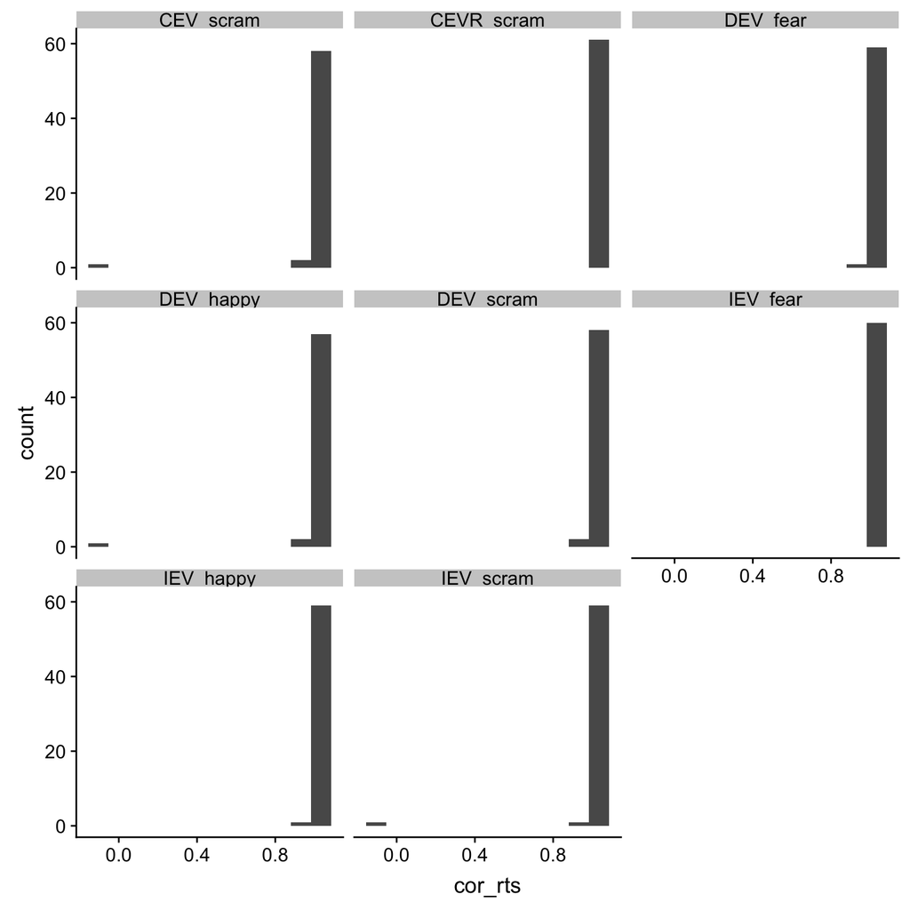

```r
cor_diagnosis <- cor_diagnosis %>% mutate(rt_csv_fillin=if_else(rt_csv==0 & rt_backcalc > 3950, rt_backcalc, rt_csv))
results <- cor_diagnosis %>% group_by(id, condition) %>% summarize(cor_rts=cor_match(rt_csv_fillin, rt_backcalc)) %>% ungroup()

ggplot(results, aes(x=cor_rts)) + geom_histogram(bins=12) + facet_wrap(~condition)
```

This is definitely moving in the right direction, but there are occasional low values. For further diagnosis:

```r
results %>% filter(cor_rts < .999)
```

| id | condition | cor_rts |
| --- | --- | --- |
| 10637_20140312 | DEV_fear | 0.979 |
| 10638_20140516 | CEV_scram | 0.999 |
| 10891_20140925 | DEV_scram | 0.998 |
| 11228_20140911 | DEV_happy | 0.980 |
| 11246_20140218 | CEV_scram | 0.950 |
| 11246_20140218 | DEV_happy | 0.954 |
| 11246_20140218 | DEV_scram | 0.931 |
| 11250_20140422 | DEV_scram | 0.999 |
| 11253_20140219 | IEV_scram | -0.137 |
| 11262_20140312 | DEV_fear | 0.998 |
| 11262_20140312 | DEV_happy | 0.998 |
| 11263_20140324 | DEV_happy | 0.999 |
| 11265_20140923 | DEV_fear | 0.999 |
| 11265_20140923 | DEV_scram | 0.997 |
| 11279_20140507 | IEV_happy | 0.998 |
| 11282_20141030 | DEV_scram | 0.999 |
| 11287_20140522 | DEV_fear | 0.998 |
| 11314_20141020 | CEV_scram | -0.059 |
| 11314_20141020 | DEV_happy | -0.061 |
| 11314_20141020 | IEV_scram | 0.990 |
| 11323_20141209 | IEV_happy | 0.999 |
| 11326_20141006 | CEV_scram | 0.928 |
| 11328_20141023 | CEVR_scram | 0.991 |
| 11343_20150110 | DEV_happy | 0.999 |
| 11343_20150110 | IEV_happy | 0.981 |
| 11343_20150110 | IEV_scram | 0.951 |
| 11350_20141204 | DEV_scram | 0.947 |